Let’s manipulate weekly decomposed data.

```r
Trend=decomp_week$trend
Seasonal=decomp_week$seasonal
Random=decomp_week$random
stationaritytest=ur.kpss(Random)
summary(stationaritytest)
```

```
##
## #######################
## # KPSS Unit Root Test #
## #######################
##
## Test is of type: mu with 18 lags.
##
## Value of test-statistic is: 0.0042
##
## Critical value for a significance level of:
##                 10pct  5pct 2.5pct  1pct
## critical values 0.347 0.463  0.574 0.739
```

We have low test-statistic so, data is stationary. Now we check ACF and PACF.

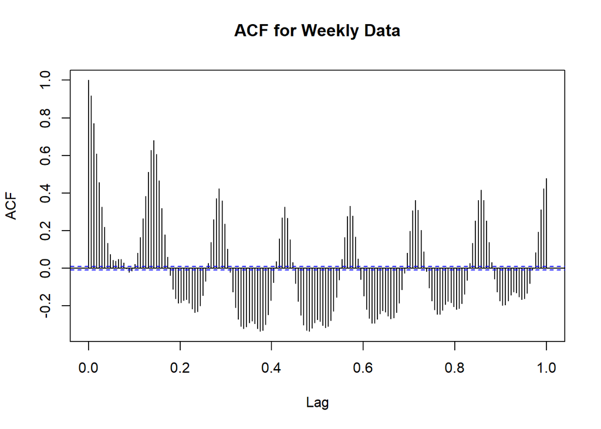

```r
acf(Random, lag.max = 168, na.action = na.pass,  main = " ACF for Weekly Data ")
```

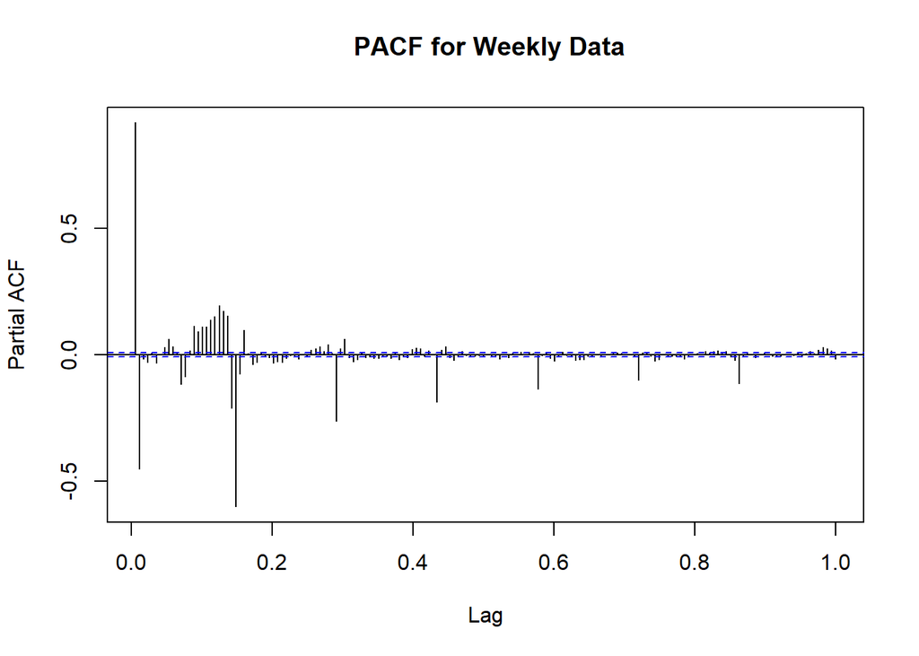

```r
pacf(Random, lag.max = 168, na.action = na.pass,  main = " PACF for Weekly Data")
```

ACF graph decreaswes exponentially. We can see a spike at lag 2. Try some Autoregressive models, priority p value is 2.

```r
ar1=arima(Random, order=c(2,0,0))
AIC(ar1)
```

```
## [1] 722906
```

```r
ar2=arima(Random, order=c(1,0,0))
AIC(ar2)
```

```
## [1] 733654.4
```

```r
ar3=arima(Random, order=c(3,0,0))
AIC(ar3)
```

```
## [1] 722896.7
```

```r
ar4=arima(Random, order=c(4,0,0))
AIC(ar4)
```

```
## [1] 722855.1
```

```r
ar5=arima(Random, order=c(5,0,0))
AIC(ar5)
```

```
## [1] 722855.1
```

Let’s try some average models.

```r
ma1=arima(Random, order=c(0,0,1))
AIC(ma1)
```

```
## [1] 771819.8
```

```r
ma2=arima(Random, order=c(0,0,2))
AIC(ma2)
```

```
## [1] 747445.1
```

```r
ma3=arima(Random, order=c(0,0,3))

AIC(ma3)
```

```
## [1] 734563
```

```r
ma4=arima(Random, order=c(0,0,4))
AIC(ma4)
```

```
## [1] 728972.5
```

```r
ma5=arima(Random, order=c(0,0,5))
AIC(ma5)
```

```
## [1] 725530.1
```

MA5 has the lowest AIC value, 725530.1.

Combine AR and MA models (4,0,5) and (5,0,5), (5,0,4).

```r
arima1=arima(Random, order=c(4,0,5))
AIC(arima1)
```

```
## [1] 722820.8
```

```r
arima2=arima(Random, order=c(5,0,5))
AIC(arima2)
```

```
## [1] 722820.5
```

```r
arima3=arima(Random, order=c(5,0,4))
AIC(arima3)
```

```
## [1] 722829.4
```

Second ARIMA model has a little less value. Let’s check residuals first and make forecasts with that. We can forecast for 420 step (84+14*24).

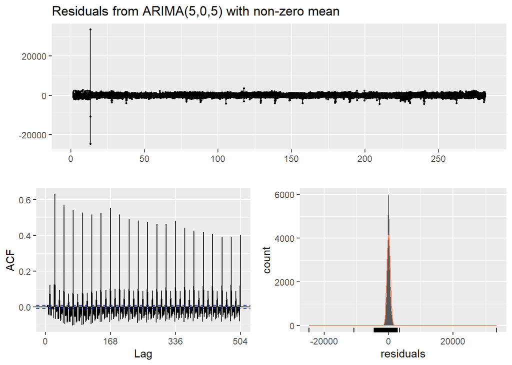

```
##
##  Ljung-Box test
##
## data:  Residuals from ARIMA(5,0,5) with non-zero mean
## Q* = 232595, df = 325, p-value < 2.2e-16
##
## Model df: 11.   Total lags used: 336
```

```r
checkresiduals(arima2)
```

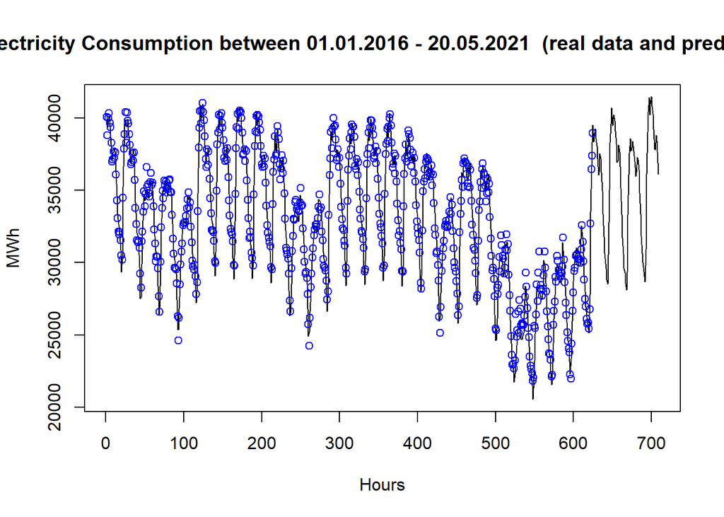

```r
fitted= Random - arima2$residuals
transformed_fitted = fitted + Trend + Seasonal
forecast = predict(arima2, n.ahead = 420)$pred
forecast_ts = ts(forecast, frequency = 168, start=c(279,85))
last=transformed_fitted[46500:47208]
plot(cons_week[46500:47208], type = "line", main = "Electricity Consumption between 01.01.2016 - 20.05.2021  (real data and prediction)", ylab = "MWh", xlab = "Hours")
points(last, col="blue")
```

```r
tren = tail(Trend[!is.na(Trend)],1)
tail(Seasonal,1)
```

```
## Time Series:
## Start = c(281, 168)
## End = c(281, 168)
## Frequency = 168
## [1] 1075.342
```

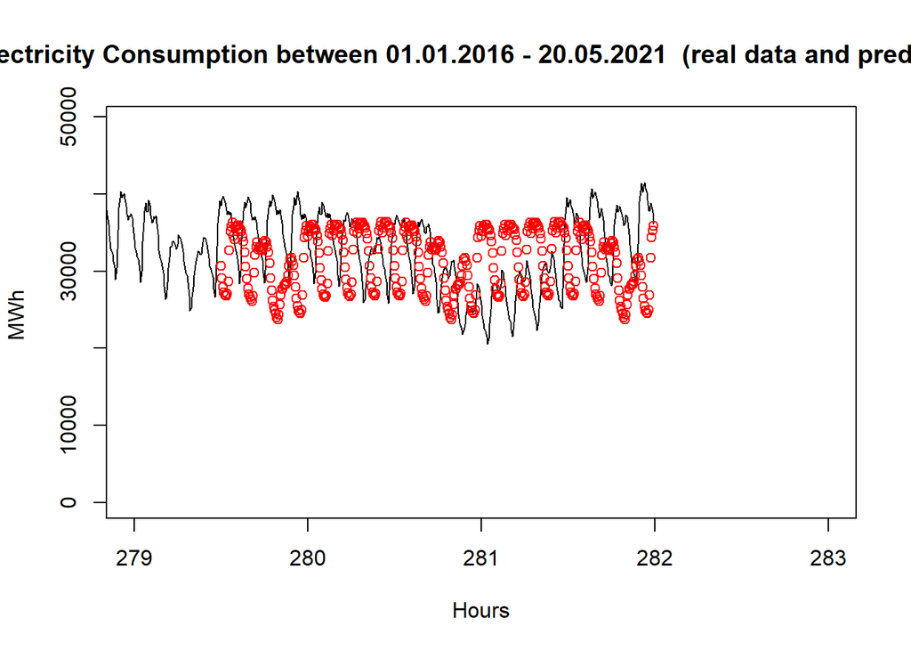

```r
season = Seasonal[1:420]
forecas = forecast_ts + tren + season
plot(cons_week, type= "line", ylab = "MWh ", xlab = "Hours", main="Electricity Consumption between 01.01.2016 - 20.05.2021  (real data and prediction)", xlim=c(279,283))
points(forecas, col = "red")
```

Let’s calculate the errors.

```r
real_data = cons[46873:47208]
error = real_data - forecas[85:420]
daily_error=0
daily_real=0

daily_error[1] = sum(error[1:24])
daily_real[1] = sum(real_data[1:24])


  for(i in 1:13){
  a=i*24
  daily_error[i] = sum(error[a:(a+24)])
  daily_real[i] = sum(real_data[a:(a+24)])
  i=i+1
  }


daily_error
```

```
##  [1]   41757.631  -36110.262    9528.323   37698.407   -1016.274  -94743.060
##  [7] -165510.415 -140382.119 -118876.842   15872.623   86024.917  125784.806
## [13]  178929.550
```

```r
daily_real
```

```
##  [1] 862811.5 789367.0 835404.5 841751.1 738084.2 631716.5 652243.1 680671.7
##  [9] 706600.4 841748.8 890077.6 864885.3 905389.1
```

```r
daily_error=abs(daily_error)

MAPE = abs(daily_error)*100/daily_real
MAPE
```

```
##  [1]  4.8397166  4.5745846  1.1405639  4.4785695  0.1376908 14.9977174
##  [7] 25.3755709 20.6240561 16.8237715  1.8856721  9.6648784 14.5435244
## [13] 19.7627233
```

Daily bias is above.

```r
sum_error = sum(daily_error[1:13])
sum_real = sum(daily_real[1:13])

WMAPE = sum_error*100/sum_real
WMAPE
```

```
## [1] 10.27498
```

Weighted mean absolute percentage error is above.